# **PART A**

**DOMAIN:** Electronics and Telecommunication

**CONTEXT:** A communications equipment manufacturing company has a product which is responsible for emitting informative signals. Company wants to build a machine learning model which can help the company to predict the equipment’s signal quality using various parameters.

**DATA DESCRIPTION:** The data set contains information on various signal tests performed:

1. Parameters: Various measurable signal parameters.
2. Signal_Quality: Final signal strength or quality

**PROJECT OBJECTIVE:** To build a classifier which can use the given parameters to determine the signal strength or quality.

```python
from google.colab import drive
drive.mount('/content/drive')
```

```python
!pip install keras-tuner
```

```
     ━━━━━━━━━━━━━━━━━━━━━━━━━━━━━━━━━━━━━━━━ 129.1/129.1 kB 2.8 MB/s eta 0:00:00
```

```python
!pip install keras==2.12.0
```

[output not shown]

```python
import pandas as pd
import numpy as np
import matplotlib.pyplot as plt
import seaborn as sns

from sklearn.preprocessing import StandardScaler, MinMaxScaler,LabelEncoder, OneHotEncoder
from sklearn.compose import ColumnTransformer
from sklearn.impute import SimpleImputer
from sklearn import metrics
from sklearn.metrics import confusion_matrix
from sklearn import model_selection
from sklearn.model_selection import train_test_split, GridSearchCV, RandomizedSearchCV
from sklearn.pipeline import Pipeline

import tensorflow as tf
import keras
from tensorflow import keras
from tensorflow.keras import layers
from tensorflow.keras.models import Sequential
from tensorflow.keras.layers import Dense, Input, Dropout, BatchNormalization
from tensorflow.keras.wrappers.scikit_learn import KerasClassifier
from tensorflow.keras import backend
from keras_tuner.tuners import RandomSearch
from keras.utils import to_categorical

import random
random.seed(1)
np.random.seed(1)
tf.random.set_seed(1)

import warnings
warnings.filterwarnings("ignore")
```

**Part 1. 1 a** - Read the ‘Signals.csv’ as DataFrame and import required libraries

```python
Signal_Data = pd.read_csv('/content/drive/MyDrive/DataScience/Deep Learning/Project/NN Project Data - Signal.csv')
print("Total no of features in the input dataset are {}, and rows {}".format(Signal_Data.shape[1], Signal_Data.shape[0]))
print("*"*60)
print(Signal_Data.info())
print("*"*60)
Signal_Data.head()
```

```
Total no of features in the input dataset are 12, and rows 1599
<class 'pandas.core.frame.DataFrame'>
RangeIndex: 1599 entries, 0 to 1598
Data columns (total 12 columns):
 #   Column           Non-Null Count  Dtype
---  ------           --------------  -----
 0   Parameter 1      1599 non-null   float64
 1   Parameter 2      1599 non-null   float64
 2   Parameter 3      1599 non-null   float64
 3   Parameter 4      1599 non-null   float64
 4   Parameter 5      1599 non-null   float64
 5   Parameter 6      1599 non-null   float64
 6   Parameter 7      1599 non-null   float64
 7   Parameter 8      1599 non-null   float64
 8   Parameter 9      1599 non-null   float64
 9   Parameter 10     1599 non-null   float64
 10  Parameter 11     1599 non-null   float64
 11  Signal_Strength  1599 non-null   int64
dtypes: float64(11), int64(1)
memory usage: 150.0 KB
None
```

|  | Parameter 1 | Parameter 2 | Parameter 3 | Parameter 4 | Parameter 5 | Parameter 6 | Parameter 7 | Parameter 8 | Parameter 9 | Parameter 10 | Parameter 11 | Signal_Strength |
| --- | --- | --- | --- | --- | --- | --- | --- | --- | --- | --- | --- | --- |
| 0 | 7.4 | 0.70 | 0.00 | 1.9 | 0.076 | 11.0 | 34.0 | 0.9978 | 3.51 | 0.56 | 9.4 | 5 |
| 1 | 7.8 | 0.88 | 0.00 | 2.6 | 0.098 | 25.0 | 67.0 | 0.9968 | 3.20 | 0.68 | 9.8 | 5 |
| 2 | 7.8 | 0.76 | 0.04 | 2.3 | 0.092 | 15.0 | 54.0 | 0.9970 | 3.26 | 0.65 | 9.8 | 5 |
| 3 | 11.2 | 0.28 | 0.56 | 1.9 | 0.075 | 17.0 | 60.0 | 0.9980 | 3.16 | 0.58 | 9.8 | 6 |
| 4 | 7.4 | 0.70 | 0.00 | 1.9 | 0.076 | 11.0 | 34.0 | 0.9978 | 3.51 | 0.56 | 9.4 | 5 |

- Total features : 12 (11 independent features and 1 Target feature -Signal Strength)
- Total rows : 1599
- All the independent features are of Float and Target feature is Integer.
- Input feature 'Parameter 3' has value '0'. It could be missing or geniune value.

**Part 1.1 b** - Check for missing values and print percentage for each attribute

```python
# Checking for missing values and % in the data
missing_count = Signal_Data.isna().sum()
missing_percentages =  (missing_count * 100 / len(Signal_Data)).round(2)
not_missing_count = len(Signal_Data) - missing_count
missing_df = pd.DataFrame({'populated_rows':not_missing_count,'missing_count':missing_count,'missing_%':missing_percentages})
print(missing_df)
print("*"*60)
```

```
                 populated_rows  missing_count  missing_%
Parameter 1                1599              0        0.0
Parameter 2                1599              0        0.0
Parameter 3                1599              0        0.0
Parameter 4                1599              0        0.0
Parameter 5                1599              0        0.0
Parameter 6                1599              0        0.0
Parameter 7                1599              0        0.0
Parameter 8                1599              0        0.0
Parameter 9                1599              0        0.0
Parameter 10               1599              0        0.0
Parameter 11               1599              0        0.0
Signal_Strength            1599              0        0.0
```

- There are no missing values / percentages in the dataset
- Note: Parameter 3 has '0' values , but we can't for certain say its missing or genuine value. So checking for the distribution of '0' values in Parameter

```python
# Checking for 'Parameter 3' 0 value percentage and  their distribution over  tje Target Feature
print(Signal_Data['Parameter 3'].value_counts() / Signal_Data['Parameter 3'].count() * 100)
print("*"*60)
print(Signal_Data.groupby('Parameter 3')['Signal_Strength'].value_counts())
print("*"*60)
```

```
Parameter 3
0.00    8.255159
0.49    4.252658
0.24    3.189493
0.02    3.126954
0.26    2.376485
          ...
0.72    0.062539
0.62    0.062539
0.75    0.062539
1.00    0.062539
0.78    0.062539
Name: count, Length: 80, dtype: float64
Parameter 3  Signal_Strength
0.00         5                  57
             6                  54
             4                  10
             7                   8
             3                   3
                                ..
0.76         7                   2
             5                   1
0.78         6                   1
0.79         5                   1
1.00         4                   1
Name: count, Length: 253, dtype: int64
```

- About 8% of rows have ZEROES
- ZERO rows are spread across all the Target Features
- Since we don't have enough understanding of these parameters and the possible values, not imputing the Zeroes.

**Part 1.1 c** - Check for presence of duplicate records in the dataset and impute with appropriate method.

```python
# Checking for duplicate rows
print("*"*60)
print("No of duplicate rows in the dataset : ",Signal_Data.duplicated().sum())
print("*"*60)

# Imputing by Dropping the duplicate rows
Signal_Data = Signal_Data.drop_duplicates().reset_index(drop=True)

print("No of duplicate rows in the dataset : ",Signal_Data.duplicated().sum())
print("*"*60)
print("No of rows in the dataset : ",len(Signal_Data))
```

```
No of duplicate rows in the dataset :  240
No of duplicate rows in the dataset :  0
No of rows in the dataset :  1359
```

**Part 1.1 d** - Visualise distribution of the target variable.

```python
# Utitlizing the barplot formatting code snippet from the Case study
def labeled_barplot(data, feature, perc=False, n=None):
    total = len(data[feature])  # length of the column
    count = data[feature].nunique()
    if n is None:
        plt.figure(figsize=(count + 1, 5))
    else:
        plt.figure(figsize=(n + 1, 5))

    plt.xticks(rotation=90, fontsize=15)
    ax = sns.countplot(
        data=data,
        x=feature,
        palette="Paired",
        order=data[feature].value_counts().index[:n].sort_values(),
    )

    for p in ax.patches:
        if perc == True:
            label = "{:.1f}%".format(
                100 * p.get_height() / total
            )  # percentage of each class of the category
        else:
            label = p.get_height()  # count of each level of the category

        x = p.get_x() + p.get_width() / 2  # width of the plot
        y = p.get_height()  # height of the plot

        ax.annotate(
            label,
            (x, y),
            ha="center",
            va="center",
            size=12,
            xytext=(0, 5),
            textcoords="offset points",
        )  # annotate the percentage

    plt.show()  # show the plot
```

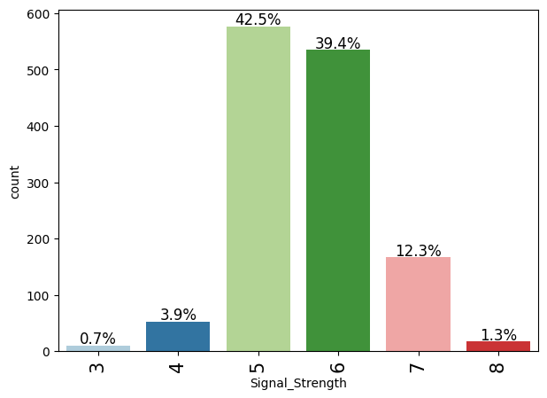

```python
labeled_barplot(Signal_Data, "Signal_Strength",True)
```

**Part 1.1 e** - Share insights from the initial data analysis (at least 2).

- Input dataset contains 11 independent and 1 target feature
- After dropping duplicate rows, there are 1359 rows
- There are no missing values, expect feature 'Parameter 3' which contain about 8% of Zeroes and these are accepted as valid values.
- Target feature has 6 categories, of which 95% of the data is spread across 3 categories.

**Part 1.2 a** - Split the data into X & Y..

```python
# Splitting Independent and Target Features
X = Signal_Data.drop(['Signal_Strength'],axis=1)
Y = Signal_Data[['Signal_Strength']]
print("Independent Features ------------------>\n", X.head())
print("*"*60)
print("Target Feature ------------------>\n", Y.head())
```

```
Independent Features ------------------>
    Parameter 1  Parameter 2  Parameter 3  Parameter 4  Parameter 5  \
0          7.4         0.70         0.00          1.9        0.076
1          7.8         0.88         0.00          2.6        0.098
2          7.8         0.76         0.04          2.3        0.092
3         11.2         0.28         0.56          1.9        0.075
4          7.4         0.66         0.00          1.8        0.075

   Parameter 6  Parameter 7  Parameter 8  Parameter 9  Parameter 10  \
0         11.0         34.0       0.9978         3.51          0.56
1         25.0         67.0       0.9968         3.20          0.68
2         15.0         54.0       0.9970         3.26          0.65
3         17.0         60.0       0.9980         3.16          0.58
4         13.0         40.0       0.9978         3.51          0.56

   Parameter 11
0           9.4
1           9.8
2           9.8
3           9.8
4           9.4
Target Feature ------------------>
    Signal_Strength
0                5
1                5
2                5
3                6
4                5
```

**Part 1.2 b** - Split the data into train & test with 70:30 proportion.

```python
# Splitting the dataset into the Training and Testing set using Stratify to ensure the Target variable distributions is maintained in the train/test sets.
X_train, X_test, Y_train, Y_test = train_test_split(X,Y, test_size = 0.3, random_state = 42, stratify = Y)
```

**Part 1.2 c** - Print shape of all the 4 variables and verify if train and test data is in sync.

```python
print("X_train shape : ",X_train.shape)
print("X_test shape  : ",X_test.shape)
print("Y_train shape : ",Y_train.shape)
print("Y_test shape :  ",Y_test.shape)
```

```
X_train shape :  (951, 11)
X_test shape  :  (408, 11)
Y_train shape :  (951, 1)
Y_test shape :   (408, 1)
```

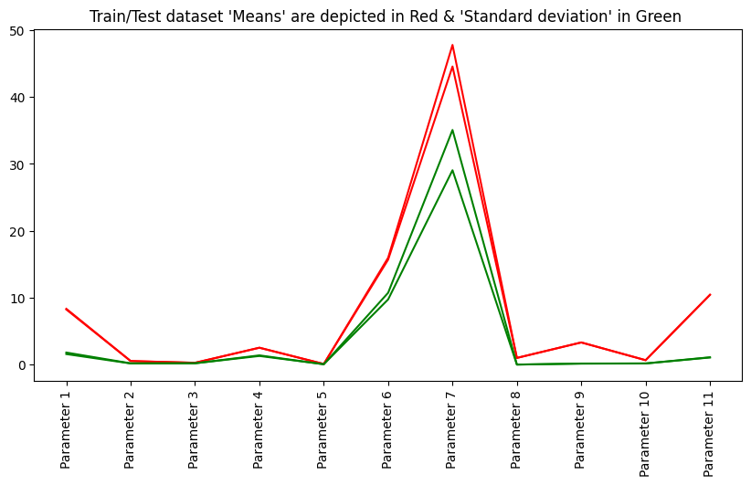

```python
# Plotting Mean and Standard deviation for X_train and X_test to verify the datasets are in sync
x_train_mean = X_train.mean()
x_test_mean = X_test.mean()
x_train_std = X_train.std()
x_test_std = X_test.std()
color = ['red','green']
comparison_df = [x_train_mean,x_test_mean,x_train_std,x_test_std]
plt.figure(figsize=(10,5))
plt.title("Train/Test dataset 'Means' are depicted in Red & 'Standard deviation' in Green ")
for i in range(0,4):
    if i in range(0,2):
        plt.plot(comparison_df[i],c=color[0])
    else:
        plt.plot(comparison_df[i],c=color[1])
    plt.xticks(rotation = 90)
```

#### * As depicted above, the characteristics (mean and standard deviation) of train and test data are similar and are in sync

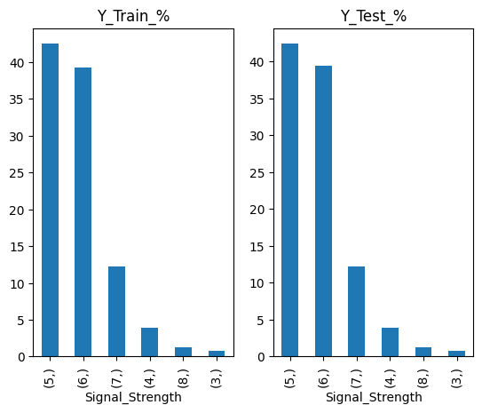

```python
# Determining value counts of each category across Y_train & Y_test
Y_train_percnt = Y_train.value_counts() / len(Y_train) * 100
Y_test_percnt = Y_test.value_counts() / len(Y_test) * 100

Y_train_test = pd.DataFrame({'Y_Train_%':Y_train_percnt,'Y_Test_%':Y_test_percnt})

#Plotting to visualize the distribution
plt.subplot(1, 2, 1)
Y_train_test['Y_Train_%'].plot(kind='bar', title='Y_Train_%')
plt.subplot(1, 2, 2)

Y_train_test['Y_Test_%'].plot(kind='bar', title='Y_Test_%')
plt.show()
```

#### * As depicted above, the distribution Target feature categories are insync between the train and test datasets.

**Part 1.2 d** - Normalise the train and test data with appropriate method..

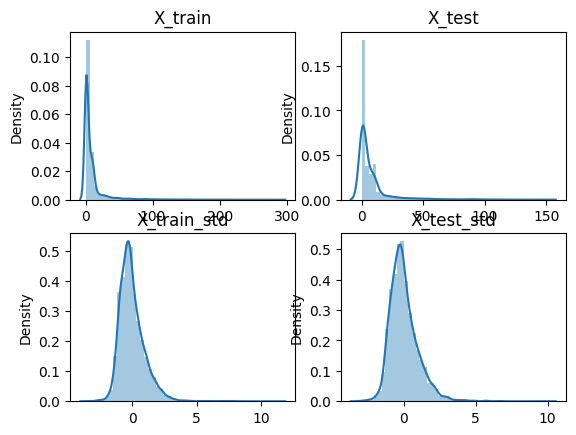

```python
# Normailizing the X datasets using StandardScaler
X_train_std = X_train.copy()
X_test_std = X_test.copy()

scale = StandardScaler()
for i in X_train.columns:
    X_train_std[i] = scale.fit_transform(X_train_std[[i]])
    X_test_std[i] = scale.fit_transform(X_test_std[[i]])

#Plotting to check the distribution of original and normalized datasets
plt.subplot(2, 2, 1)
plt.title('X_train')
sns.distplot(X_train, kde=True)
plt.subplot(2, 2, 2)
plt.title('X_test')
sns.distplot(X_test,kde=True)
plt.subplot(2, 2, 3)
plt.title('X_train_std')
sns.distplot(X_train_std)
plt.subplot(2, 2, 4)
plt.title('X_test_std')
sns.distplot(X_test_std);
```

- Data is Normalized using Standardscaler

**Part 1.2 e** - Transform Labels into format acceptable by Neural Network

```python
# Converting Target features Numeric categories into Categorical variable
Y_train_cat = to_categorical(Y_train)
Y_test_cat = to_categorical(Y_test)

print ("Y_train \n",Y_train_cat[0:5])
print ("*"*60)
print ("Y_test \n",Y_test_cat[0:5])
```

```
Y_train
 [[0. 0. 0. 0. 0. 1. 0. 0. 0.]
 [0. 0. 0. 0. 0. 0. 1. 0. 0.]
 [0. 0. 0. 0. 0. 1. 0. 0. 0.]
 [0. 0. 0. 0. 0. 0. 1. 0. 0.]
 [0. 0. 0. 0. 0. 0. 1. 0. 0.]]
Y_test
 [[0. 0. 0. 0. 0. 1. 0. 0. 0.]
 [0. 0. 0. 0. 0. 0. 1. 0. 0.]
 [0. 0. 0. 0. 0. 0. 1. 0. 0.]
 [0. 0. 0. 0. 0. 0. 1. 0. 0.]
 [0. 0. 0. 0. 0. 1. 0. 0. 0.]]
```

- Target variable is converted using One-Hot encoding to better suit NN.

**Part 1.3 a** - Design a Neural Network to train a classifier.

```python
backend.clear_session()
np.random.seed(42)
import random
random.seed(42)
tf.random.set_seed(42)
```

```python
# Building Base Neural Network using Activation function 'sigmoid'
model = Sequential()

model.add(Dense(activation = 'sigmoid', input_dim = 11,units=64))
model.add(Dense(32, activation='sigmoid'))
model.add(Dense(9, activation = 'softmax'))

# Compiling the Base NN
model.compile(optimizer='SGD', loss='categorical_crossentropy', metrics=['accuracy'])
```

```python
model.summary()
```

```
Model: "sequential"
_________________________________________________________________
 Layer (type)                Output Shape              Param #
=================================================================
 dense (Dense)               (None, 64)                768

 dense_1 (Dense)             (None, 32)                2080

 dense_2 (Dense)             (None, 9)                 297

=================================================================
Total params: 3,145
Trainable params: 3,145
Non-trainable params: 0
_________________________________________________________________
```

**Part 1.3 b** - Train the classifier using previously designed Architecture

```python
history = model.fit(X_train_std, Y_train_cat, validation_split=0.2, epochs=50, batch_size=100,verbose=1)
```

**Part 1.3 c** - Plot 2 separate visuals. i) Training Loss and Validation Loss ii) Training Accuracy and Validation Accuracy

```
 Model Performance on Test data ->
```

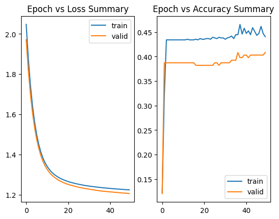

```python
# Capturing learning history per epoch
hist  = pd.DataFrame(history.history)
hist['epoch'] = history.epoch

#Printing results
print (" Model Performance on Test data ->")
print ("*"*60)
results = model.evaluate(X_test_std, Y_test_cat)

# Plotting Train & Validation Loss at different epochs
plt.subplot(1, 2, 1)
plt.title('Epoch vs Loss Summary')
plt.plot(hist['loss'])
plt.plot(hist['val_loss'])
plt.legend(("train" , "valid") , loc =0)

# Plotting Train & Validation Accuracy at different epochs
plt.subplot(1, 2, 2)
plt.title('Epoch vs Accuracy Summary')
plt.plot(hist['accuracy'])
plt.plot(hist['val_accuracy'])
plt.legend(("train" , "valid") , loc =0)
plt.show();
```

- While Loss of Train and Validation sets are comparable, the accuracies of Train and Validation sets are slighty off indicating the model is slightly overfit

```python
# Predicting the model on X_test
y_pred=model.predict(X_test_std)
y_pred[0]
```

```
array([0.01141602, 0.0071693 , 0.00486717, 0.01081984, 0.03012901,
       0.452537  , 0.3539265 , 0.11312659, 0.01600855], dtype=float32)
```

```python
# Since softmax returns probabilities, setting the output class to the class with highest probability
y_pred_final=[]
for i in y_pred:
  y_pred_final.append(np.argmax(i))

print("Final Predicution : ",y_pred_final[0])
print("Actual Value      : ",Y_test_cat[0])
```

```
Final Predicution :  5
Actual Value      :  [0. 0. 0. 0. 0. 1. 0. 0. 0.]
```

```python
#Base model Classification report
class_rept =metrics.classification_report(Y_test,y_pred_final)
print(class_rept)
```

```
              precision    recall  f1-score   support

           3       0.00      0.00      0.00         3
           4       0.00      0.00      0.00        16
           5       0.44      0.94      0.60       173
           6       0.39      0.09      0.14       161
           7       0.00      0.00      0.00        50
           8       0.00      0.00      0.00         5

    accuracy                           0.43       408
   macro avg       0.14      0.17      0.12       408
weighted avg       0.34      0.43      0.31       408
```

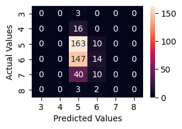

```python
cm = confusion_matrix(Y_test,y_pred_final)
cm_df = pd.DataFrame (cm,index = ['3','4','5','6','7','8'], columns = ['3','4','5','6','7','8'])

plt.figure(figsize=(3,2))
sns.heatmap(cm_df,annot=True,fmt='d')
plt.xlabel('Predicted Values')
plt.ylabel('Actual Values');
```

- Base NN Model with 'SGD' Optimier and 'sigmoid' Activation function has returned an Accuracy of 42% on the given dataset,
- Model has identified two class '5' & '6'.
- Also has seen in the earlier steps the model is slightly overfit.

**Part 1.3 d** - Design new architecture/update existing architecture in attempt to improve the performance of the model.

```python
# Resetting the session
backend.clear_session()
np.random.seed(101)
random.seed(101)
tf.random.set_seed(101)
```

```python
# Defining Hypertuned NN model
def create_h_model(lr,batch_size):
    np.random.seed(101)
    model_h = Sequential()
    model_h.add(Dense(128,activation='relu',input_dim = 11,kernel_initializer='he_uniform'))
    model_h.add(BatchNormalization())
    model_h.add(Dropout(0.5))
    model_h.add(Dense(64,activation='relu',kernel_initializer='he_uniform'))
    model_h.add(BatchNormalization())
    model_h.add(Dropout(0.5))
    model_h.add(Dense(64,activation='relu',kernel_initializer='he_uniform'))
    model_h.add(BatchNormalization())
    model_h.add(Dropout(0.5))
    model_h.add(Dense(32,activation='relu',kernel_initializer='he_uniform'))
    model_h.add(BatchNormalization())
    model_h.add(Dropout(0.5))
    model_h.add(Dense(9, activation='softmax'))

#Compiling NN model with Adam optimizer
    optimizer = tf.keras.optimizers.Adam(learning_rate=lr)
    model_h.compile(optimizer = optimizer,loss = 'categorical_crossentropy', metrics = ['accuracy'])
    return model_h
```

```python
# defining KerasClassifier
keras_estimator = KerasClassifier(build_fn=create_h_model, verbose=1)

# setting GridSreachCV
param_grid = {'batch_size':[50,100,150],"lr":[0.01,0.1,0.001,0.05]}
kfold_splits = 2
grid = GridSearchCV(estimator=keras_estimator,verbose=1,cv=kfold_splits,param_grid=param_grid,n_jobs=-1)
```

```python
import time
# starting time
begin = time.time()

grid_result = grid.fit(X_train_std, Y_train_cat,validation_split=0.3,verbose=1)

# Summarizing results
print("Best: %f using %s" % (grid_result.best_score_, grid_result.best_params_))
means = grid_result.cv_results_['mean_test_score']
stds = grid_result.cv_results_['std_test_score']
params = grid_result.cv_results_['params']

time.sleep(1)
# end time
end = time.time()

# total time taken
print(f"Total runtime of the program is {end - begin}")
```

```
Fitting 2 folds for each of 12 candidates, totalling 24 fits
Best: 0.333324 using {'batch_size': 50, 'lr': 0.01}
Total runtime of the program is 93.44329857826233
```

```python
model_h = create_h_model(lr=grid_result.best_params_['lr'],batch_size=grid_result.best_params_['batch_size'])
model_h.summary()
```

```
Model: "sequential_1"
_________________________________________________________________
 Layer (type)                Output Shape              Param #
=================================================================
 dense_5 (Dense)             (None, 128)               1536

 batch_normalization_4 (Batc  (None, 128)              512
 hNormalization)

 dropout_4 (Dropout)         (None, 128)               0

 dense_6 (Dense)             (None, 64)                8256

 batch_normalization_5 (Batc  (None, 64)               256
 hNormalization)

 dropout_5 (Dropout)         (None, 64)                0

 dense_7 (Dense)             (None, 64)                4160

 batch_normalization_6 (Batc  (None, 64)               256
 hNormalization)

 dropout_6 (Dropout)         (None, 64)                0

 dense_8 (Dense)             (None, 32)                2080

 batch_normalization_7 (Batc  (None, 32)               128
 hNormalization)

 dropout_7 (Dropout)         (None, 32)                0

 dense_9 (Dense)             (None, 9)                 297

=================================================================
Total params: 17,481
Trainable params: 16,905
Non-trainable params: 576
_________________________________________________________________
```

```python
optimizer = tf.keras.optimizers.Adam(grid_result.best_params_['lr'])
model_h.compile(loss='categorical_crossentropy',optimizer=optimizer,metrics=['accuracy'])
history_h=model_h.fit(X_train_std, Y_train_cat, epochs=100, batch_size = grid_result.best_params_['batch_size'], verbose=1,validation_split=0.3)
```

**Part 1.3 e** - Plot visuals as in Q3.C and share insights about difference observed in both the models.

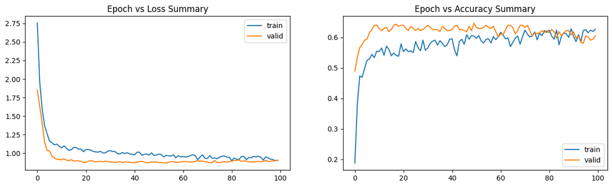

```python
# Capturing learning history per epoch
hist_h  = pd.DataFrame(history_h.history)
hist_h['epoch'] = history_h.epoch

#Printing results
results_h = model_h.evaluate(X_test_std, Y_test_cat)

plt.figure(figsize=(15,4))
# Plotting Train & Validation Loss at different epochs
plt.subplot(1, 2, 1)
plt.title('Epoch vs Loss Summary')
plt.plot(hist_h['loss'])
plt.plot(hist_h['val_loss'])
plt.legend(("train" , "valid") , loc =0)

# Plotting Train & Validation Accuracy at different epochs
plt.subplot(1, 2, 2)
plt.title('Epoch vs Accuracy Summary')
plt.plot(hist_h['accuracy'])
plt.plot(hist_h['val_accuracy'])
plt.legend(("train" , "valid") , loc =0)
plt.show();
```

```python
# Predicting the model on X_test
y_pred_h=model_h.predict(X_test_std)
y_pred_h[0]

# Since softmax returns probabilities, setting the output class to the class with highest probability
y_pred_final_h = []
for i in y_pred_h:
  y_pred_final_h.append(np.argmax(i))

print("Final Prediction : ",y_pred_final_h[0])
print ("Actual Value    : ",Y_test_cat[0])

#Base model Classification report
class_rept_h =metrics.classification_report(Y_test,y_pred_final_h)
print(class_rept_h)
```

```
Final Prediction :  5
Actual Value    :  [0. 0. 0. 0. 0. 1. 0. 0. 0.]
              precision    recall  f1-score   support

           3       0.00      0.00      0.00         3
           4       0.00      0.00      0.00        16
           5       0.63      0.73      0.68       173
           6       0.54      0.61      0.57       161
           7       0.48      0.20      0.28        50
           8       0.00      0.00      0.00         5

    accuracy                           0.58       408
   macro avg       0.27      0.26      0.26       408
weighted avg       0.54      0.58      0.55       408
```

- After applying BatchNormalization & Dropout regularization techniques, he performance of the Model has improved. Train and Validation sets scores are similar, indicating model is not completely overfit.
- The overall performance of the model is greatly increased with an Accuracy of 59% with +/- 2%.

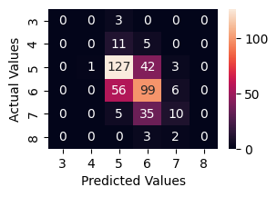

```python
cm_h = confusion_matrix(Y_test,y_pred_final_h)
cm_h_df = pd.DataFrame (cm_h,index = ['3','4','5','6','7','8'], columns = ['3','4','5','6','7','8'])

plt.figure(figsize=(3,2))
sns.heatmap(cm_h_df,annot=True,fmt='d')
plt.xlabel('Predicted Values')
plt.ylabel('Actual Values');
```

# Insights

**Base NN Model:**

- Followed a simple architecture with

  ```
  Two Hidden layer (64 and 32 neurons)
  Activation Function : Sigmoid
  Optimizer : Stochastic Gradient Descent (SGD)
  ```

**Updated Model NN:**

- Model performed very similar with both Train and Validation sets indicating its not over/under fit.
- Model Accuracy increased nearly by 20% to 60% and was able to identify the majority classes.

# **PART B**

**DOMAIN:** Autonomous Vehicles

**CONTEXT:** A Recognising multi-digit numbers in photographs captured at street level is an important component of modern-day map making. A classic example of a corpus of such street-level photographs is Google’s Street View imagery composed of hundreds of millions of geo-located 360-degree panoramic images. The ability to automatically transcribe an address number from a geo-located patch of pixels and associate the transcribed number with a known street address helps pinpoint, with a high degree of accuracy, the location of the building it represents. More broadly, recognising numbers in photographs is a problem of interest to the optical character recognition community. While OCR on constrained domains like document processing is well studied, arbitrary multi-character text recognition in photographs is still highly challenging. This difficulty arises due to the wide variability in the visual appearance of text in the wild on account of a large range of fonts, colours, styles, orientations, and character arrangements. The recognition problem is further complicated by environmental factors such as lighting, shadows, specularity, and occlusions as well as by image acquisition factors such as resolution, motion, and focus blurs. In this project, we will use the dataset with images centred around a single digit (many of the images do contain some distractors at the sides). Although we are taking a sample of the data which is simpler, it is more complex than MNIST because of the distractors.

**DATA DESCRIPTION:** The SVHN is a real-world image dataset for developing machine learning and object recognition algorithms with the minimal requirement on data formatting but comes from a significantly harder, unsolved, real-world problem (recognising digits and numbers in natural scene images). SVHN is obtained from house numbers in Google Street View images. Where the labels for each of this image are the prominent number in that image i.e. 2,6,7 and 4 respectively. The dataset has been provided in the form of h5py files. You can read about this file format here: https://docs.h5py.org/en/stable/ Acknowledgement: Yuval Netzer, Tao Wang, Adam Coates, Alessandro Bissacco, Bo Wu, Andrew Y. Ng Reading Digits in Natural Images with Unsupervised Feature Learning NIPS Workshop on Deep Learning and Unsupervised Feature Learning 2011. PDF http://ufldl.stanford.edu/housenumbers as the URL for this site.

**PROJECT OBJECTIVE:** To build a digit classifier on the SVHN (Street View Housing Number) dataset.

**Part 2.1 a** - Read the .h5 file and assign to a variable.

```python
!pip install h5py
import h5py
```

```python
hf = h5py.File('/content/drive/MyDrive/DataScience/Deep Learning/Project/Autonomous_Vehicles_SVHN_single_grey1.h5', 'r')
```

**Part 2.1 b** - Print all the keys from the .h5 file.

```python
print("Keys of the H5 dataset are: %s" % hf.keys())
```

```
Keys of the H5 dataset are: <KeysViewHDF5 ['X_test', 'X_train', 'X_val', 'y_test', 'y_train', 'y_val']>
```

**Part 2.1 c** - Split the data into X_train, X_test, Y_train, Y_test

```python
X_train = hf.get('X_train')
X_test = hf.get('X_test')
Y_train = hf.get('y_train')
Y_test = hf.get('y_test')
```

**Part 2.2 a** - Print shape of all the 4 data split into x, y, train, test to verify if x & y is in sync..

```python
print("X_train shape : ",X_train.shape)
print("X_test shape  : ",X_test.shape)
print("Y_train shape : ",Y_train.shape)
print("Y_test shape :  ",Y_test.shape)
```

```
X_train shape :  (42000, 32, 32)
X_test shape  :  (18000, 32, 32)
Y_train shape :  (42000,)
Y_test shape :   (18000,)
```

- X_train and Y_train have 42000 rows. X_test and Y_test have 18000 rows and are in sync.
- Target feature would require One-hot encoding.

**Part 2.2 b** - Visualise first 10 images in train data and print its corresponding labels

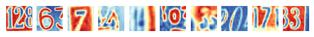

```
Label for each of the above image: [2 6 7 4 4 0 3 0 7 3]
```

```python
# Visualizing the first 10 images in the train dataset and associated labels
for i in range(10):
    plt.subplot(1, 10, i+1)
    plt.imshow(X_train[i], cmap="RdYlBu")
    plt.axis('off')
plt.show()
print('Label for each of the above image: %s' % (Y_train[0:10]))
```

**Part 2.2 c** - Reshape all the images with appropriate shape update the data in same variable.

```python
# Reshaping X datasets
print("X_train shape : ",X_train.shape)
print("X_test shape  : ",X_test.shape)

X_train_np = np.array(X_train)
X_train_np = X_train_np.reshape(X_train_np.shape[0],-1);
print("X_train_np shape : ",X_train_np.shape)

X_test_np = np.array(X_test)
X_test_np = X_test_np.reshape(X_test_np.shape[0],-1)

print("X_test_np shape  : ",X_test_np.shape)
```

```
X_train shape :  (42000, 32, 32)
X_test shape  :  (18000, 32, 32)
X_train_np shape :  (42000, 1024)
X_test_np shape  :  (18000, 1024)
```

```python
print(X_train[0])
X_train_np[0]
```

```
[[ 33.0704  30.2601  26.852  ...  71.4471  58.2204  42.9939]
 [ 25.2283  25.5533  29.9765 ... 113.0209 103.3639  84.2949]
 [ 26.2775  22.6137  40.4763 ... 113.3028 121.775  115.4228]
 ...
 [ 28.5502  36.212   45.0801 ...  24.1359  25.0927  26.0603]
 [ 38.4352  26.4733  23.2717 ...  28.1094  29.4683  30.0661]
 [ 50.2984  26.0773  24.0389 ...  49.6682  50.853   53.0377]]
```

```
array([33.0704, 30.2601, 26.852 , ..., 49.6682, 50.853 , 53.0377],
      dtype=float32)
```

**Part 2.2 d** - Normalise the images i.e. Normalise the pixel values.

```python
# Normalizing the pixel values  (from 0-255 to 0-1)
X_train_np = X_train_np / 255.0
X_test_np = X_test_np / 255.0

print("X_train_np shape : ",X_train_np.shape)
print("X_test_np shape  : ",X_test_np.shape)
```

```
X_train_np shape :  (42000, 1024)
X_test_np shape  :  (18000, 1024)
```

```python
X_train_np[0]
```

```
array([0.12968785, 0.11866706, 0.10530196, ..., 0.19477727, 0.19942354,
       0.20799099], dtype=float32)
```

**Part 2.2 e** - Transform Labels into format acceptable by Neural Network

```python
# Transforming Target variable into categorical values that be intepreted by NN model
num_classes = 10
Y_train_cat = to_categorical(Y_train, num_classes)
Y_test_cat = to_categorical(Y_test,num_classes)
```

**Part 2.2 f** - Print total Number of classes in the Dataset.

```python
# Displaying the shapes of the datasets after transformation
print("X_train_np shape  : ",X_train_np.shape,"\nX_test_np shape  : ",X_test_np.shape,"\nY_train_cat shape  : ",Y_train_cat.shape,
      "\nY_test_cat shape  : ",Y_test_cat.shape)
```

```
X_train_np shape  :  (42000, 1024)
X_test_np shape  :  (18000, 1024)
Y_train_cat shape  :  (42000, 10)
Y_test_cat shape  :  (18000, 10)
```

**Part 2.3 a** - Design a Neural Network to train a classifier.

```python
# Defining the model
backend.clear_session()
np.random.seed(42)
random.seed(42)
tf.random.set_seed(42)

mlm = Sequential()
mlm.add(Dense(256, activation='relu', input_shape = (32*32,)))
mlm.add(Dense(128, activation='relu'))
mlm.add(Dense(64, activation='relu'))
mlm.add(Dense(32, activation='relu'))
mlm.add(Dense(num_classes, activation = 'softmax'))
```

```python
#Compiling the model
sgd_optimizer = tf.keras.optimizers.SGD(learning_rate=0.001)
mlm.compile(optimizer=sgd_optimizer,loss='categorical_crossentropy',metrics=['accuracy'])
mlm.summary()
```

```
Model: "sequential"
_________________________________________________________________
 Layer (type)                Output Shape              Param #
=================================================================
 dense (Dense)               (None, 256)               262400

 dense_1 (Dense)             (None, 128)               32896

 dense_2 (Dense)             (None, 64)                8256

 dense_3 (Dense)             (None, 32)                2080

 dense_4 (Dense)             (None, 10)                330

=================================================================
Total params: 305,962
Trainable params: 305,962
Non-trainable params: 0
_________________________________________________________________
```

```python
mlm_history = mlm.fit(X_train_np,Y_train_cat,validation_split=0.2,batch_size = 210,epochs=25,verbose = 1)
```

```
 Model Performance on Test data ->
```

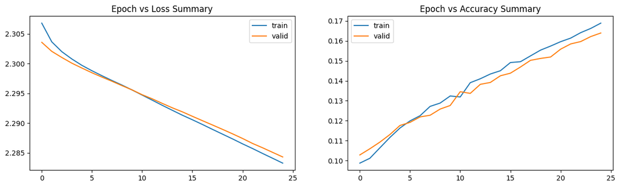

```python
# Capturing learning history per epoch
hist  = pd.DataFrame(mlm_history.history)
hist['epoch'] = mlm_history.epoch

#Printing results
print (" Model Performance on Test data ->")
print ("*"*60)
results = mlm.evaluate(X_test_np, Y_test_cat)

plt.figure(figsize=(15,4))
# Plotting Train & Validation Loss at different epochs
plt.subplot(1, 2, 1)
plt.title('Epoch vs Loss Summary')
plt.plot(hist['loss'])
plt.plot(hist['val_loss'])
plt.legend(("train" , "valid"))

# Plotting Train & Validation Accuracy at different epochs
plt.subplot(1, 2, 2)
plt.title('Epoch vs Accuracy Summary')
plt.plot(hist['accuracy'])
plt.plot(hist['val_accuracy'])
plt.legend(("train" , "valid") , loc =0)
plt.show();
```

```
Final Predicution :  9
Actual Value      :  1
Final Predicution :  1
Actual Value      :  7
Final Predicution :  2
Actual Value      :  2
Final Predicution :  9
Actual Value      :  9
Final Predicution :  3
Actual Value      :  0
Final Predicution :  2
Actual Value      :  9
Final Predicution :  5
Actual Value      :  1
Final Predicution :  4
Actual Value      :  8
Final Predicution :  1
Actual Value      :  4
Final Predicution :  4
Actual Value      :  4
```

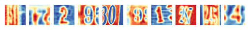

```python
# Predicting the model on X_test
y_pred=mlm.predict(X_test_np)
y_pred[0]

# Since softmax returns probabilities, setting the output class to the class with highest probability
y_pred_final=[]
for i in y_pred:
  y_pred_final.append(np.argmax(i))


for i in range(10):
    plt.subplot(1, 10, i+1)
    plt.imshow(X_test[i], cmap="RdYlBu")
    print("Final Predicution : ",y_pred_final[i])
    print("Actual Value      : ",Y_test[i])
    plt.axis('off')
plt.show()
```

```
              precision    recall  f1-score   support

           0       0.16      0.07      0.10      1814
           1       0.20      0.29      0.24      1828
           2       0.12      0.19      0.15      1803
           3       0.12      0.40      0.18      1719
           4       0.33      0.33      0.33      1812
           5       0.22      0.11      0.15      1768
           6       0.10      0.01      0.01      1832
           7       0.22      0.16      0.19      1808
           8       0.14      0.10      0.12      1812
           9       0.15      0.03      0.05      1804

    accuracy                           0.17     18000
   macro avg       0.18      0.17      0.15     18000
weighted avg       0.18      0.17      0.15     18000
```

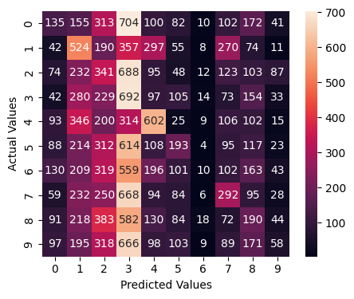

```python
#Base model Classification report
class_rept =metrics.classification_report(Y_test,y_pred_final)
print(class_rept)

cm = confusion_matrix(Y_test,y_pred_final)
cm_df = pd.DataFrame (cm,index = ['0','1','2','3','4','5','6','7','8','9'], columns = ['0','1','2','3','4','5','6','7','8','9'])

plt.figure(figsize=(5,4))
sns.heatmap(cm_df,annot=True,fmt='d')
plt.xlabel('Predicted Values')
plt.ylabel('Actual Values');
```

For Base model, followed below architecture

- Four Hidden layer (256,128,64 and 32 neurons)
- Activation Function : Relu
- Optimizer : Stochastic Gradient Descent (SGD)
- Learning Rate : 0.001
- Batch Size : 210
- Epochs : 25

There was not significant learning over Epochs. But the accuracy increased slightly with a final score of 17% for test sets.

**Part 2.3 b** - Train the classifier using previously designed Architecture (Use best suitable parameters).

```python
# Resetting the session
backend.clear_session()
np.random.seed(102)
random.seed(102)
tf.random.set_seed(102)
```

```python
# Defining Hypertuned NN model
def create_h_mlm(lr,batch_size):
    np.random.seed(102)
    mlm_h = Sequential()
    mlm_h.add(Dense(1024, activation='relu',kernel_initializer='he_uniform',input_shape=(32*32,)))
    mlm_h.add(BatchNormalization())
    mlm_h.add(Dropout(0.3))
    mlm_h.add(Dense(512, activation='relu',kernel_initializer='he_uniform'))
    mlm_h.add(BatchNormalization())
    mlm_h.add(Dropout(0.3))
    mlm_h.add(Dense(256, activation='relu',kernel_initializer='he_uniform'))
    mlm_h.add(BatchNormalization())
    mlm_h.add(Dropout(0.3))
    mlm_h.add(Dense(64, activation='relu',kernel_initializer='he_uniform'))
    mlm_h.add(BatchNormalization())
    mlm_h.add(Dropout(0.3))
    mlm_h.add(Dense(32, activation='relu',kernel_initializer='he_uniform'))
    mlm_h.add(BatchNormalization())
    mlm_h.add(Dropout(0.3))
    mlm_h.add(Dense(num_classes, activation='softmax'))
# Compiling the model
    o_adam = tf.keras.optimizers.Adam(learning_rate=lr, amsgrad = True)
    mlm_h.compile(loss='categorical_crossentropy', optimizer=o_adam, metrics=['accuracy'])
    return mlm_h
```

```python
# Defining KerasClassifier
keras_estimator = KerasClassifier(build_fn=create_h_mlm, verbose=1)

# Setting GridSreachCV
param_grid = {'batch_size':[128,256,512],"lr":[0.01,0.1,0.001]}
kfold_splits = 2
grid = GridSearchCV(estimator=keras_estimator,verbose=1,cv=kfold_splits,param_grid=param_grid,n_jobs=-1)

import time
# starting time
begin = time.time()

grid_result = grid.fit(X_train_np, Y_train_cat,validation_split=0.2,verbose=1)

# Summarizing results
print("Best: %f using %s" % (grid_result.best_score_, grid_result.best_params_))
means = grid_result.cv_results_['mean_test_score']
stds = grid_result.cv_results_['std_test_score']
params = grid_result.cv_results_['params']

time.sleep(1)
# end time
end = time.time()

# total time taken
print(f"Total runtime of the program is {end - begin}")
```

```
Fitting 2 folds for each of 9 candidates, totalling 18 fits
Best: 0.133024 using {'batch_size': 128, 'lr': 0.001}
Total runtime of the program is 257.63461089134216
```

```python
# Defining the final model
mlm_h = create_h_mlm(lr=grid_result.best_params_['lr'],batch_size=grid_result.best_params_['batch_size'])
mlm_h.summary()
```

```
Model: "sequential_1"
_________________________________________________________________
 Layer (type)                Output Shape              Param #
=================================================================
 dense_6 (Dense)             (None, 1024)              1049600

 batch_normalization_5 (Batc  (None, 1024)             4096
 hNormalization)

 dropout_5 (Dropout)         (None, 1024)              0

 dense_7 (Dense)             (None, 512)               524800

 batch_normalization_6 (Batc  (None, 512)              2048
 hNormalization)

 dropout_6 (Dropout)         (None, 512)               0

 dense_8 (Dense)             (None, 256)               131328

 batch_normalization_7 (Batc  (None, 256)              1024
 hNormalization)

 dropout_7 (Dropout)         (None, 256)               0

 dense_9 (Dense)             (None, 64)                16448

 batch_normalization_8 (Batc  (None, 64)               256
 hNormalization)

 dropout_8 (Dropout)         (None, 64)                0

 dense_10 (Dense)            (None, 32)                2080

 batch_normalization_9 (Batc  (None, 32)               128
 hNormalization)

 dropout_9 (Dropout)         (None, 32)                0

 dense_11 (Dense)            (None, 10)                330

=================================================================
Total params: 1,732,138
Trainable params: 1,728,362
Non-trainable params: 3,776
_________________________________________________________________
```

```python
# Compiling the Final model
o_adam = tf.keras.optimizers.Adam(grid_result.best_params_['lr'], amsgrad = True)
mlm_h.compile(loss='categorical_crossentropy', optimizer=o_adam, metrics=['accuracy'])

# Fitting the Final model
mlm_h_history = mlm_h.fit(X_train_np,Y_train_cat,validation_split=0.3,batch_size = grid_result.best_params_['batch_size'] ,epochs=50,verbose = 1)
```

**Part 2.3 c** - Evaluate performance of the model with appropriate metrics.

```
 Model Performance on Test data ->
```

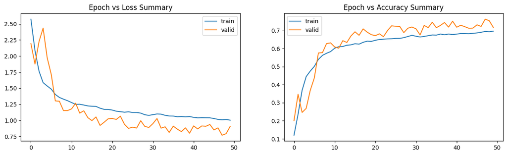

```python
# Capturing learning history per epoch
hist_h = pd.DataFrame(mlm_h_history.history)
hist_h['epoch'] = mlm_h_history.epoch

#Printing results
print (" Model Performance on Test data ->")
print ("*"*60)
results = mlm_h.evaluate(X_test_np, Y_test_cat)

plt.figure(figsize=(15,4))
# Plotting Train & Validation Loss at different epochs
plt.subplot(1, 2, 1)
plt.title('Epoch vs Loss Summary')
plt.plot(hist_h['loss'])
plt.plot(hist_h['val_loss'])
plt.legend(("train" , "valid"))

# Plotting Train & Validation Accuracy at different epochs
plt.subplot(1, 2, 2)
plt.title('Epoch vs Accuracy Summary')
plt.plot(hist_h['accuracy'])
plt.plot(hist_h['val_accuracy'])
plt.legend(("train" , "valid") , loc =0)
plt.show();
```

```
Final Predicution :  0
Actual Value      :  1
Final Predicution :  2
Actual Value      :  7
Final Predicution :  2
Actual Value      :  2
Final Predicution :  9
Actual Value      :  9
Final Predicution :  0
Actual Value      :  0
Final Predicution :  9
Actual Value      :  9
Final Predicution :  1
Actual Value      :  1
Final Predicution :  5
Actual Value      :  8
Final Predicution :  1
Actual Value      :  4
Final Predicution :  4
Actual Value      :  4
```

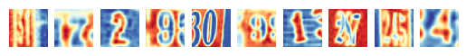

```
              precision    recall  f1-score   support

           0       0.72      0.79      0.75      1814
           1       0.78      0.76      0.77      1828
           2       0.81      0.68      0.74      1803
           3       0.72      0.68      0.70      1719
           4       0.78      0.80      0.79      1812
           5       0.60      0.76      0.67      1768
           6       0.61      0.76      0.68      1832
           7       0.72      0.80      0.76      1808
           8       0.83      0.58      0.68      1812
           9       0.79      0.64      0.71      1804

    accuracy                           0.72     18000
   macro avg       0.74      0.72      0.72     18000
weighted avg       0.74      0.72      0.73     18000
```

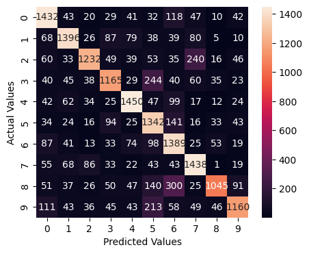

```python
# Predicting the model on X_test
y_pred_h=mlm_h.predict(X_test_np)
y_pred_h[0]

# Since softmax returns probabilities, setting the output class to the class with highest probability
y_pred_final_h = []
for i in y_pred_h:
  y_pred_final_h.append(np.argmax(i))

# Plotting first 10 results
for i in range(10):
    plt.subplot(1, 10, i+1)
    plt.imshow(X_test[i], cmap="RdYlBu")
    print("Final Predicution : ",y_pred_final_h[i])
    print("Actual Value      : ",Y_test[i])
    plt.axis('off')
plt.show()

#Tuned model Classification report
class_rept_h =metrics.classification_report(Y_test,y_pred_final_h)
print(class_rept_h)

cm_h = confusion_matrix(Y_test,y_pred_final_h)
cm_df_h = pd.DataFrame (cm_h,index = ['0','1','2','3','4','5','6','7','8','9'], columns = ['0','1','2','3','4','5','6','7','8','9'])

plt.figure(figsize=(5,4))
sns.heatmap(cm_df_h,annot=True,fmt='d')
plt.xlabel('Predicted Values')
plt.ylabel('Actual Values');
```

For Tuned model, below architecture is followed

- Five Hidden layer (1024, 512, 256, 64 and 32 neurons)
- Activation Function : Relu
- Weight Initializer : he_uniform
- Optimizer : AMSgrad
- Epochs : 50
- Best Learning Rate : 0.001 (determined using GridSearch)
- Best Batch Size : 128 (determined using GridSearch)

The performance of the tuned model has significantly improved compared to the base model with Loss dropping to ~0.8% and accuracy to 70% (+/- 2%).

**Part 2.3 d** - Plot the training loss, validation loss vs number of epochs and training accuracy, validation accuracy vs number of epochs plot and write your observations on the same.

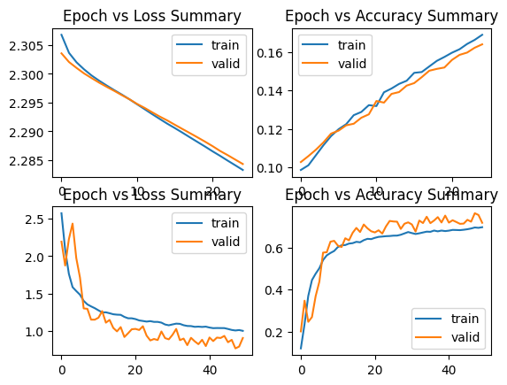

```python
# Plotting Train & Validation Loss at different epochs
plt.subplot(2, 2,1)
plt.title('Epoch vs Loss Summary')
plt.plot(hist['loss'])
plt.plot(hist['val_loss'])
plt.legend(("train" , "valid"))

# Plotting Train & Validation Accuracy at different epochs
plt.subplot(2, 2,2)
plt.title('Epoch vs Accuracy Summary')
plt.plot(hist['accuracy'])
plt.plot(hist['val_accuracy'])
plt.legend(("train" , "valid") , loc =0)

# Plotting Train & Validation Loss at different epochs
plt.subplot(2, 2,3)
plt.title('Epoch vs Loss Summary')
plt.plot(hist_h['loss'])
plt.plot(hist_h['val_loss'])
plt.legend(("train" , "valid"))

# Plotting Train & Validation Accuracy at different epochs
plt.subplot(2, 2,4)
plt.title('Epoch vs Accuracy Summary')
plt.plot(hist_h['accuracy'])
plt.plot(hist_h['val_accuracy'])
plt.legend(("train" , "valid") , loc =0)
plt.show();
```

For Base model, followed below architecture

- Four Hidden layer (256,128,64 and 32 neurons)
- Activation Function : Relu
- Optimizer : Stochastic Gradient Descent (SGD)
- Learning Rate : 0.001
- Batch Size : 210
- Epochs : 25

There was not significant learning over Epochs. But the accuracy increase slightly with a final score of 17% for test sets.

For Tuned model, below architecture is followed

- Five Hidden layer (1024,512,256,64 and 32 neurons)
- Activation Function : Relu
- Weight Initializer : he_uniform
- Optimizer : AMSgrad
- Epochs : 50
- Best Learning Rate : 0.001 (determined using GridSearch)
- Best Batch Size : 128 (determined using GridSearch)

The performance of the tuned has significantly improved compared to the base model with Loss dropping to below 1% and accuracy to 70% (+/- 2%).

# Insights

Base model Performance : Loss ~2.2% and Accuracy ~ 16% Tuned model Performance : Loss ~.8% and Accuracy ~ 72%

Both models performed very similar with Training, Validation and Test sets, indicating the models are not over/underfit.

By adjusting various parameters such as Number of Layers, Neurons in each layer, Activation function, Optimizers, Weight Initializer, Batch size and learning rate, the performance of the model has significantly increased with accuracy score of ~72%.